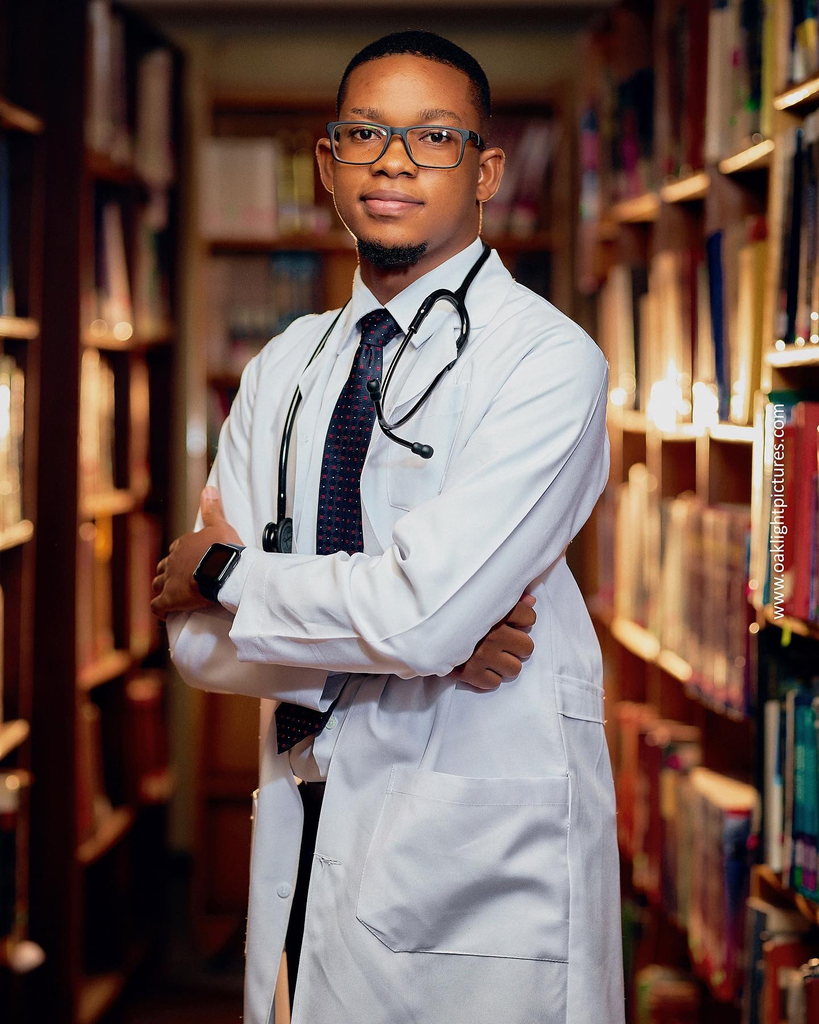

# PAUL BAKA

**BIO**

I am a medical doctor trained in Ghana and currently pursuing my Master of Public Health (MPH) at Johns Hopkins University. My long-term ambition is to become a pediatric oncologist, dedicated to improving the lives of children battling cancer. As part of my MPH journey, I have taken advanced coursework in statistical computing, with a focus on building strong programming and data analysis skills using R. I believe these skills are essential for modern medical research, especially in the age of big data and precision medicine. My research interests center on novel genetic sequencing approaches to address pediatric hematologic cancers. I am deeply motivated to explore innovative strategies that can translate cutting-edge science into practical, lifesaving therapies for children.

**FUN FACTS**

1.⚽ Football fanatic – My favorite player of all time is Lionel Messi. 2.🍳 Cooking therapy – I love cooking whenever I feel stressed. 3.🗳️ Politics enthusiast – I can talk politics all day, usually plotting ways to make Ghana a better country. 4.🌍 Travel lover – Iceland is high on my list of dream destinations. 5.⭐ Three wishes before 2026 – Meet Steph Curry, Lewis Hamilton, and of course, Lionel Messi.

**INSPIRATION**

I always find myself going back to listen to the commencement speech from Steve Jobs at standford 2005 graduation.[STEVE JOBS](https://youtu.be/UF8uR6Z6KLc?si=vz81PVVartZXF32M)

**EDUCATION**

Master of Public Health| Exp May 2026 Johns Hopkins Bloomberg School of Public Health | Baltimore, MD

Bachelor of Medicine and Bachelor of Surgery (MD Equivalent) | oct, 2022 Kwame Nkrumah University of Science and Technology | Kumasi, Ghana

Bachelor of Human Biology |July, 2019 Kwame Nkrumah University Of Science and Technology|Kumasi , Ghana